# Final Project

# Multiple regression – Model 3

# - Regress Cardiovascular Disease Prevalence on White, African American, Ozone

```
##
## Call:
## lm(formula = cardio ~ White + African_American + Ozone, data = ces4_bay_all_Demographic)
##
## Residuals:
##     Min      1Q  Median      3Q     Max
## -8.6817 -2.1870 -0.4348  1.9312 11.1419
##
## Coefficients:
##                    Estimate Std. Error t value Pr(>|t|)
## (Intercept)        1.752572   0.741665   2.363   0.0183 *
## White             -0.047829   0.003846 -12.437   <2e-16 ***
## African_American   0.164475   0.010446  15.746   <2e-16 ***
## Ozone            275.636184  18.541277  14.866   <2e-16 ***
## ---
## Signif. codes:  0 '***' 0.001 '**' 0.01 '*' 0.05 '.' 0.1 ' ' 1
##
## Residual standard error: 3.149 on 1506 degrees of freedom
## Multiple R-squared:  0.3599, Adjusted R-squared:  0.3587
## F-statistic: 282.3 on 3 and 1506 DF,  p-value: < 2.2e-16
```

# VIF measures for Model 1 ~ Model3

```
##         Hispanic African_American            Ozone
##         1.078960         1.086641         1.095418
```

```
## Education_attainment     African_American                Ozone
##             1.074834             1.119560             1.046136
```

```
##            White African_American            Ozone
##         1.204975         1.240942         1.084366
```

Result: Based on three multiple regression models, all factors are significant with p value < 0.001. The expansionary power of three multiple regression models ranges from 0.3599 (Model 3) to 0.4807 (Model 1). The VIF values for three multiple regression models are all below 5, suggesting no serious collinearity among predictors in these multiple regression line. Since “Model 1” has the highest R square, indicating it is the best tentative model at this stage.

# ——————————————————————————

# Scatter plot: Actual Cardiovascular Disease Prevalence vs. Predicted Cardiovascular Disease Prevalence

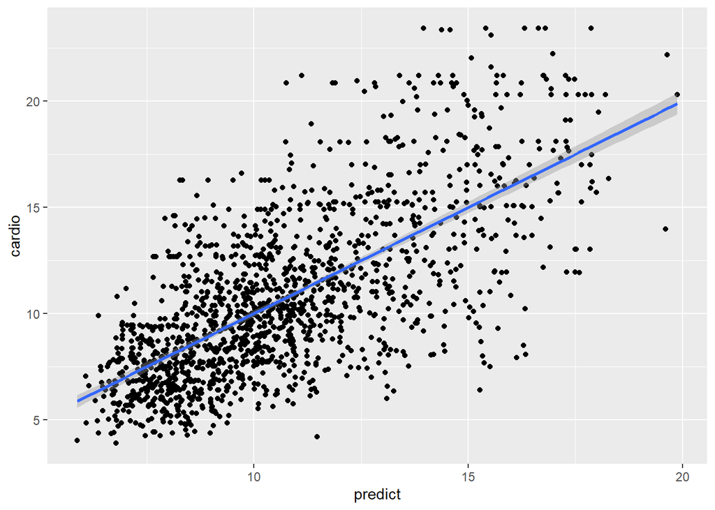

# ——————————————————————————

# Residual analysis – check the goodness of fit for Multiple Regession Model 1

# Residual density distribution

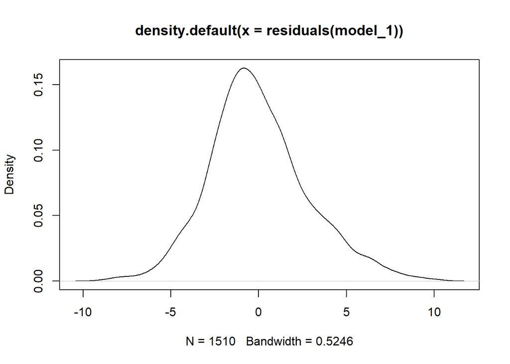

```
## [1] 9.499684e-17
```

# ——————————————————————————

# Residual scatter plot

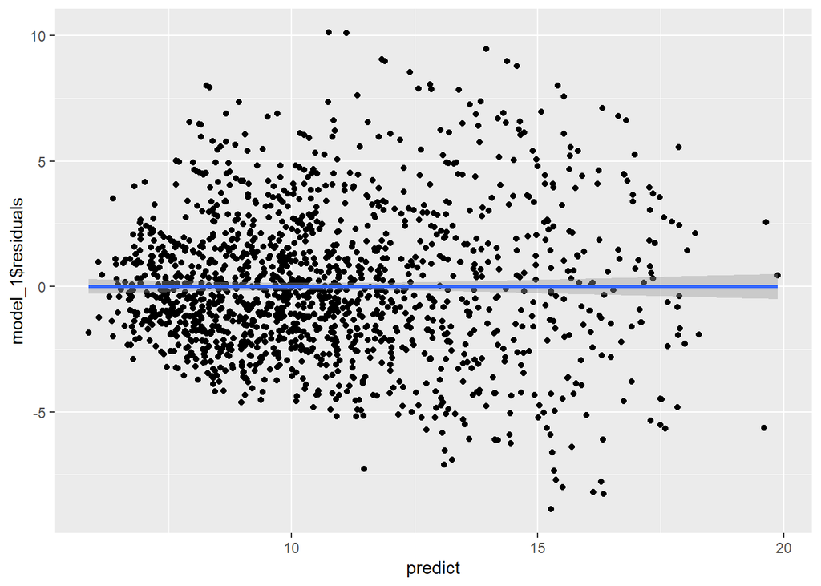

# ——————————————————————————

# Question 3: Are there any confounding effects among key risk factors? What do these confounding effect mean for the Cardiovascular Disease Prevalence?

The confounding effect can be assessed among the following factors: (1) Education attainment and Hispanic (the highest, 0.79) (2) Education attainment and Poverty (0.73) (3) Education attainment and White (-0.67) (4) Poverty and Hispanic (0.6) (5) Poverty and Unemployment rate (0.52) (6) Poverty and White (-0.48) (7) African American and Poverty (0.48) (8) African American and Unemployment rate (0.42)

# ——————————————————————————

# Confounding effect for Education attainment and Hispanic

# Plot of Cardiovascular Disease Prevalence vs. Education attainment, controling Hispanic

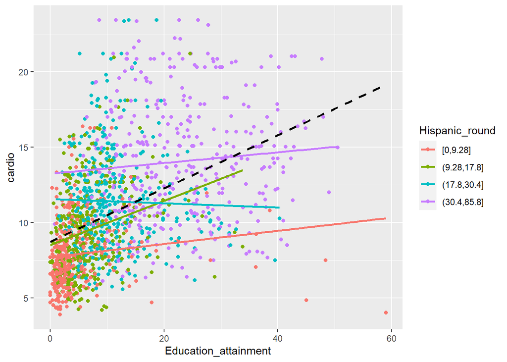

Result: Three trend lines for the four quartile categories of Hispanic percentage groups have positive slopes, but with quite different slopes. For two groups with the highest and lowest Hispanic percentages, the Education attainment is positively correlated with Cardiovascular Disease Prevalence. For the group with second lowest Hispanic percentage, the Education attainment is even more positively correlated with Cardiovascular Disease Prevalence. On the contrary, For the group with second highest Hispanic percentage, the Education attainment is negative correlated with Cardiovascular Disease Prevalence.

# ——————————————————————————

# Confounding effect for Education attainment and Poverty

# Plot of Cardiovascular Disease Prevalence vs. Education attainment, controling Poverty

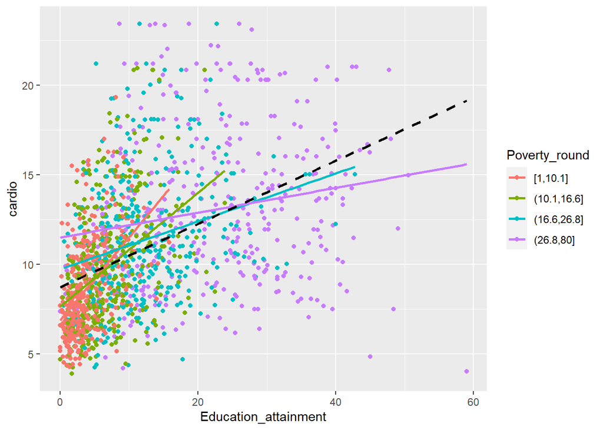

Result: Four trend lines for the four quartile categories of Poverty all have positive slopes which become smaller with the increase of Poverty percentage in the census tract. For the group with the lowest Poverty percentage, the Education attainment is strongly correlated with Cardiovascular Disease Prevalence. With the Poverty percentage increases, the correlation between Education attainment and Cardiovascular Disease Prevalence become lesser.

# ——————————————————————————

# Confounding effect for Education attainment and White

# Plot of Cardiovascular Disease Prevalence vs. Education attainment, controling White

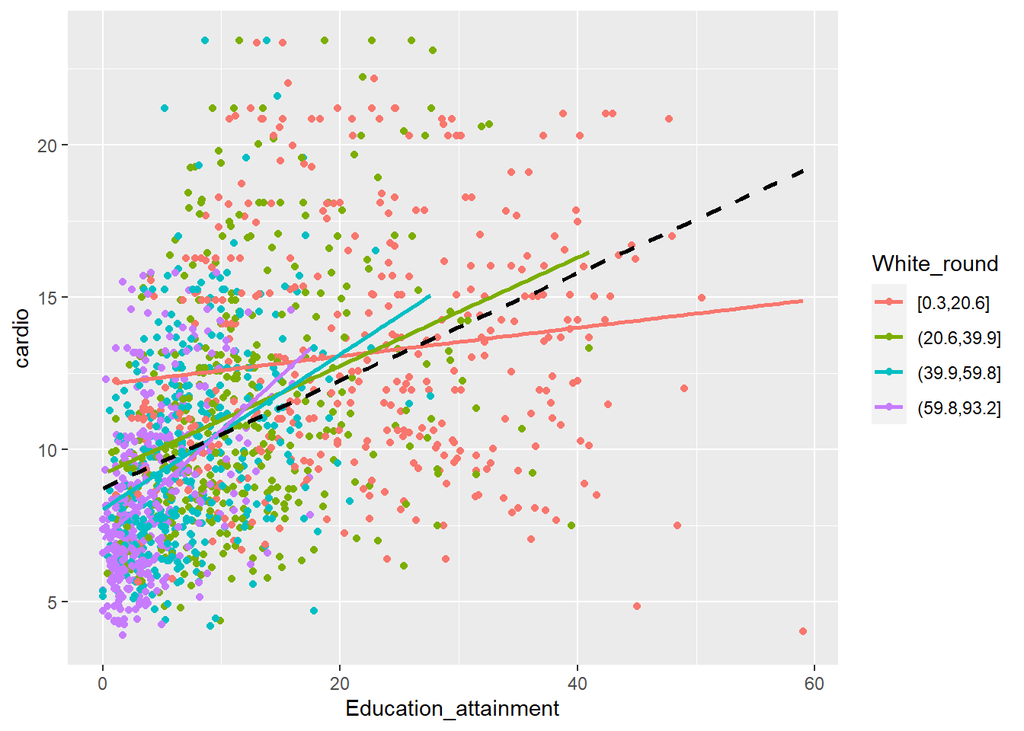

# ——————————————————————————

# Confounding effect for Poverty and Hispanic

# Plot of Cardiovascular Disease Prevalence vs. Poverty, controling Hispanic

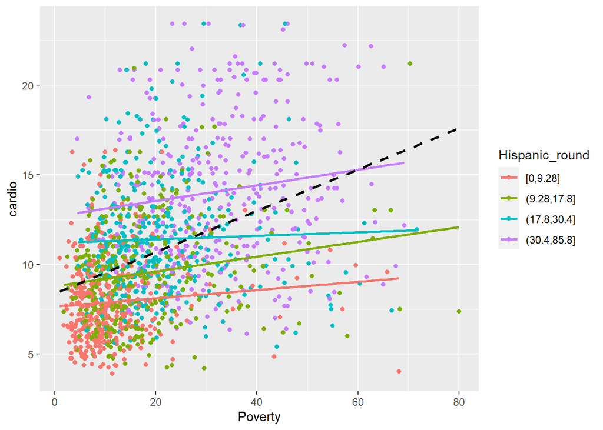

Result: Two trend lines for the groups of the highest and second lowest Hispanic percentages have positive and roughly equivalent slopes. For the group of the lowest Hispanic percentage, the Poverty is less correlated with Cardiovascular Disease Prevalence. For the group of the second highest Hispanic percentage, the Poverty is the least correlated with Cardiovascular Disease Prevalence.

# ——————————————————————————

# Confounding effect for Poverty and Unemployment rate

# Plot of Cardiovascular Disease Prevalence vs. Poverty, controling Unemployment rate

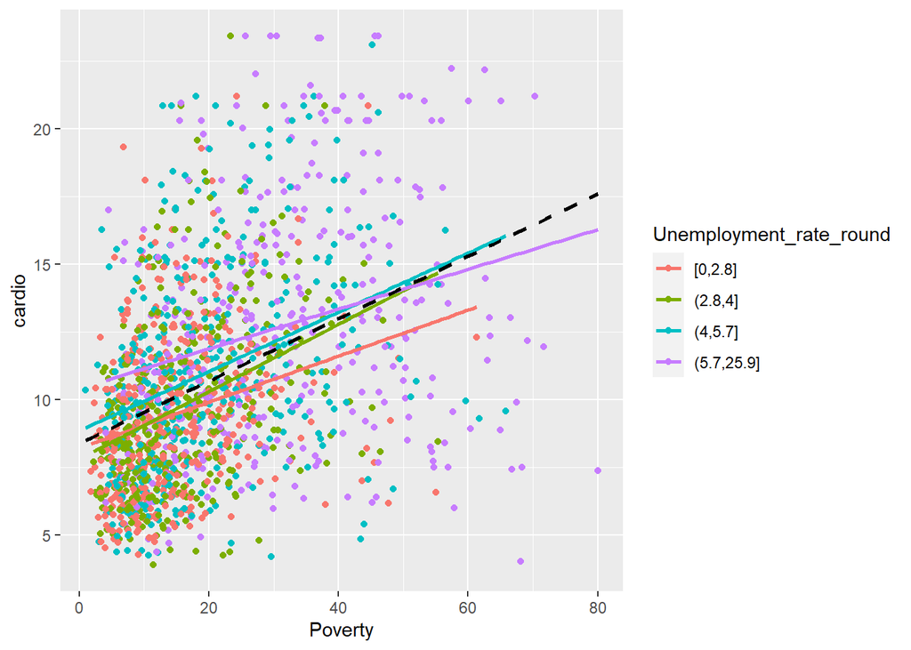

Result: The slopes of four trend lines are roughly equivalent to that of the black best-fit line. For the group with highest and the lowest percentages of Unemployment rate, the relation between Poverty and Cardiovascular Disease Prevalence is slightly lesser.

# ——————————————————————————

# Confounding effect for Poverty and White

# Plot of Cardiovascular Disease Prevalence vs. Poverty, controling White

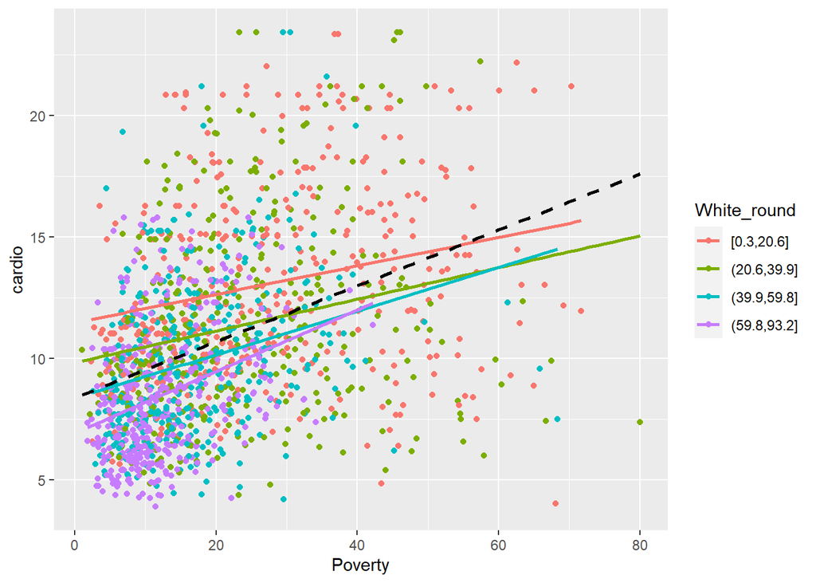

Result: For the group with the highest percentage of White, the correlation between Poverty and Cardiovascular Disease Prevalence is greater. For the other three groups, the correlation between Poverty and Cardiovascular Disease Prevalence is slightly lesser as the percentage of White in the census tract decreases.

# ——————————————————————————

# Confounding effect for Poverty and African American

# Plot of Cardiovascular Disease Prevalence vs. Poverty, controling African American

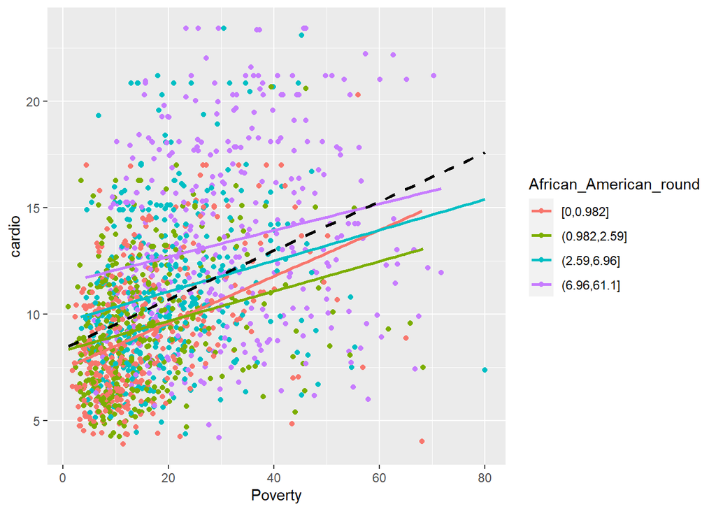

Result: For the group with the lowest percentages of African American, the relation between Poverty and Cardiovascular Disease Prevalence is slightly greater. For the other three groups, the correlation between Poverty and Cardiovascular Disease Prevalence is lesser as the percentages of African American increases,

# ——————————————————————————

# Confounding effect for Unemployment rate and African American

# Plot of Cardiovascular Disease Prevalence vs. Unemployment rate, controling African American

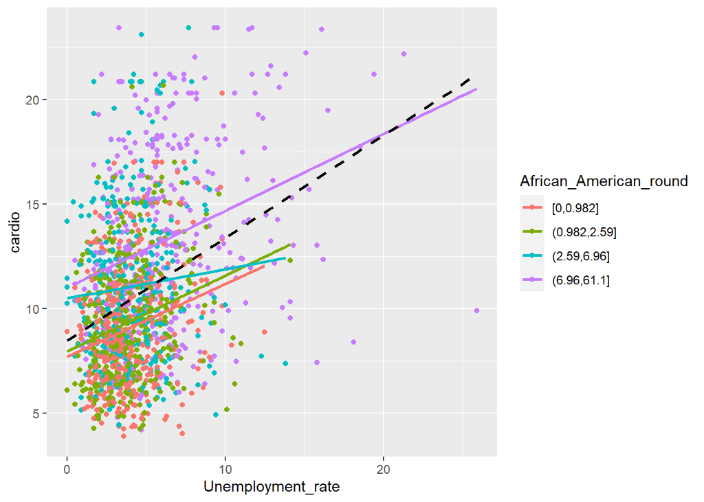

Result: For the group with the second highest percentage of African American in the range of (2.59,6.96], the Unemployment rate is less correlated with Cardiovascular Disease Prevalence. However, for the other three percentage groups of African American, the Unemployment rate is more positively correlated with Cardiovascular Disease Prevalence.

# ——————————————————————————

# The Stacked Bar Charts are illustrated to further examine confounding effect among multiple factors

# ——————————————————————————

# (1)Check confounding – Mean Cardiovascular Disease prevalence: Education attainment by Hispanic

# CES Demographic data

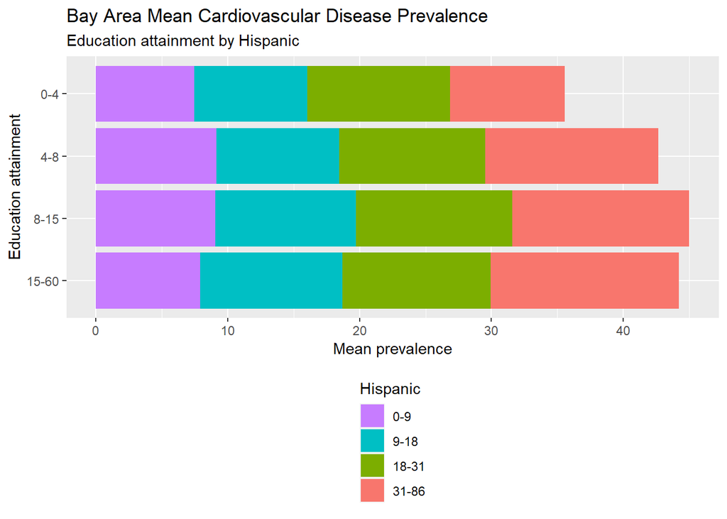

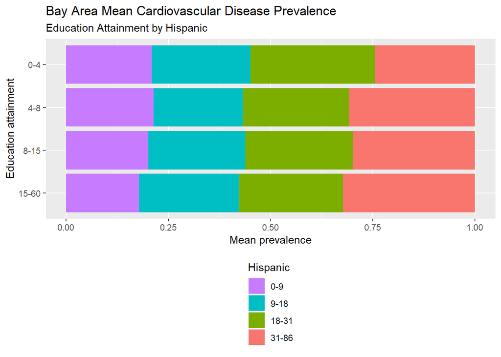

# ——————————————————————————

# (2)Check confounding – Mean Cardiovascular Disease Prevalence: Education attainment by Poverty

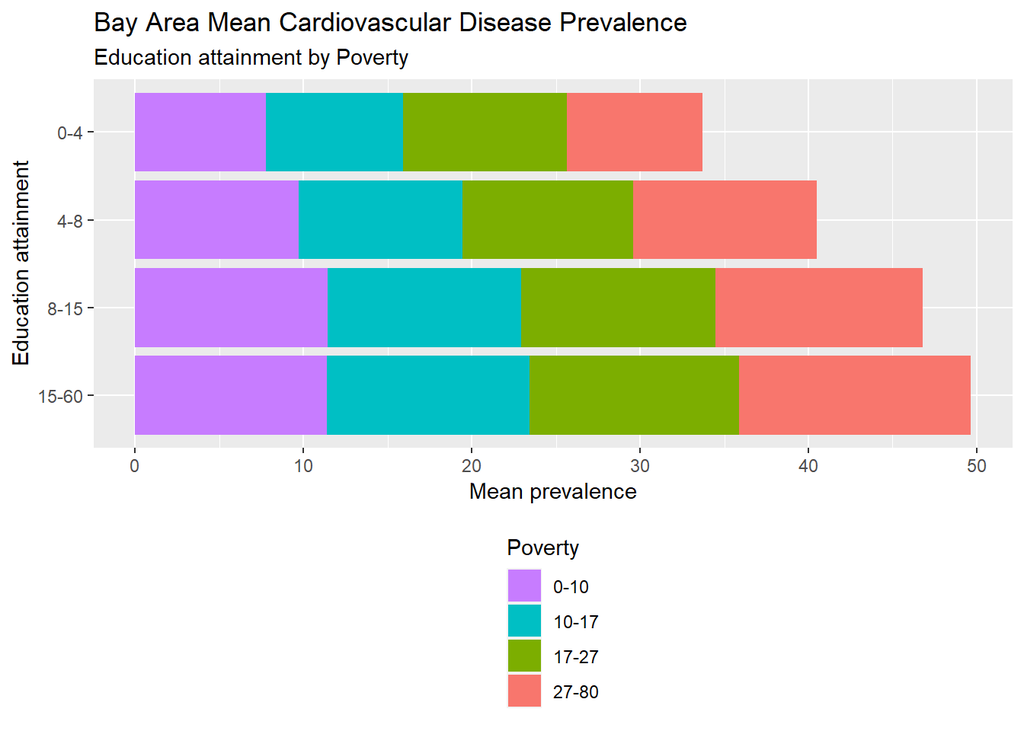

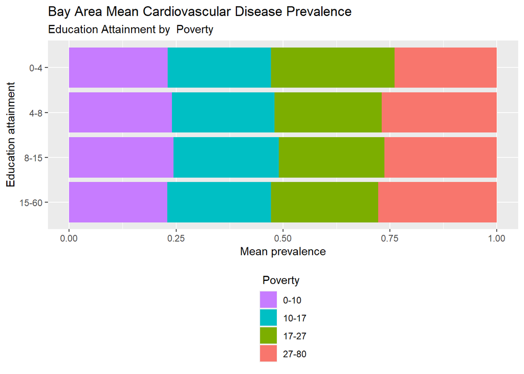

Result: As the Poverty percentage increases, the Mean Cardiovascular Disease Prevalence gets larger. As the education attainment increases, the Mean Cardiovascular Disease Prevalence gets larger, too. For the groups with higher Poverty percentage, the Mean Cardiovascular Disease Prevalence increases as Education attainment increases.

# ——————————————————————————

# (3)Check confounding – Mean Cardiovascular Disease Prevalence: Education attainment by White

[figure not shown]

[figure not shown]

# ——————————————————————————

# (4)Check confounding – Mean Cardiovascular Disease Prevalence: Poverty by Hispanic

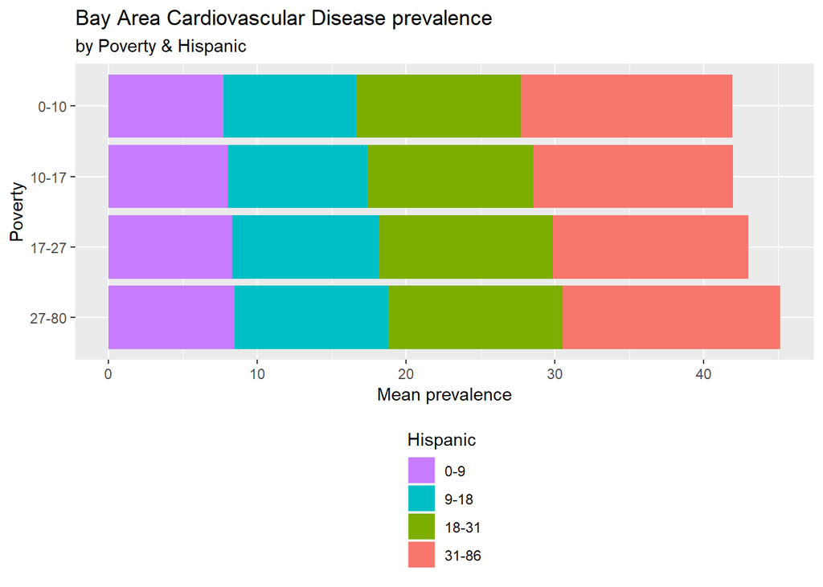

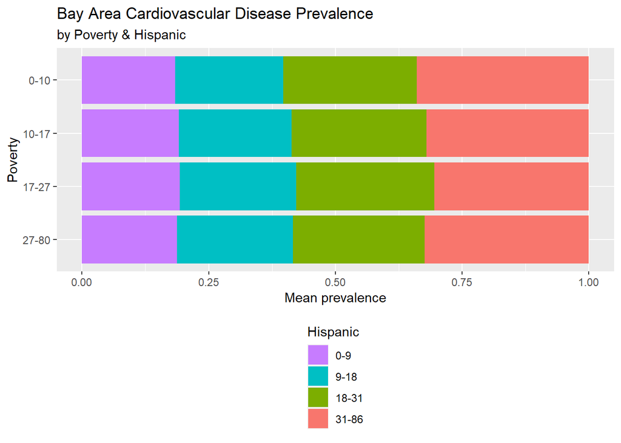

Result: As the Poverty percentage increases, the Mean Cardiovascular Disease Prevalence gets larger. For the groups with the lower Hispanic percentage,0-9, 9-18, 18-31, the Mean Cardiovascular Disease Prevalence roughly increases as the increase of Poverty. However,for the group with the highest Hispanic percentage, the Mean Cardiovascular Disease Prevalence is lower for the poverty percentage of 10-17 & 17-27.